# Examining survival rates of various passengers aboard the Titanic

```python
import pandas as pd
import numpy as np
import matplotlib.pyplot as plt
import seaborn as sns
import math
%matplotlib inline
```

Data is a subset of the Kaggle data: https://www.kaggle.com/c/titanic/data

```python
df_raw = pd.read_csv('titanic_data.csv')
```

## Getting familiar with the data

From the Kaggle site: https://www.kaggle.com/c/titanic/data

VARIABLE DESCRIPTIONS: survival Survival (0 = No; 1 = Yes) pclass Passenger Class (1 = 1st; 2 = 2nd; 3 = 3rd) name Name sex Sex age Age sibsp Number of Siblings/Spouses Aboard parch Number of Parents/Children Aboard ticket Ticket Number fare Passenger Fare cabin Cabin embarked Port of Embarkation (C = Cherbourg; Q = Queenstown; S = Southampton)

SPECIAL NOTES: Pclass is a proxy for socio-economic status (SES) 1st ~ Upper; 2nd ~ Middle; 3rd ~ Lower

Age is in Years; Fractional if Age less than One (1) If the Age is Estimated, it is in the form xx.5

With respect to the family relation variables (i.e. sibsp and parch) some relations were ignored. The following are the definitions used for sibsp and parch.

Sibling: Brother, Sister, Stepbrother, or Stepsister of Passenger Aboard Titanic Spouse: Husband or Wife of Passenger Aboard Titanic (Mistresses and Fiances Ignored) Parent: Mother or Father of Passenger Aboard Titanic Child: Son, Daughter, Stepson, or Stepdaughter of Passenger Aboard Titanic

```python
df = df_raw
df.head(3)
```

|  | PassengerId | Survived | Pclass | Name | Sex | Age | SibSp | Parch | Ticket | Fare | Cabin | Embarked |
| --- | --- | --- | --- | --- | --- | --- | --- | --- | --- | --- | --- | --- |
| 0 | 1 | 0 | 3 | Braund, Mr. Owen Harris | male | 22.0 | 1 | 0 | A/5 21171 | 7.2500 | NaN | S |
| 1 | 2 | 1 | 1 | Cumings, Mrs. John Bradley (Florence Briggs Th... | female | 38.0 | 1 | 0 | PC 17599 | 71.2833 | C85 | C |
| 2 | 3 | 1 | 3 | Heikkinen, Miss. Laina | female | 26.0 | 0 | 0 | STON/O2. 3101282 | 7.9250 | NaN | S |

```python
df.describe()
```

|  | PassengerId | Survived | Pclass | Age | SibSp | Parch | Fare |
| --- | --- | --- | --- | --- | --- | --- | --- |
| count | 891.000000 | 891.000000 | 891.000000 | 714.000000 | 891.000000 | 891.000000 | 891.000000 |
| mean | 446.000000 | 0.383838 | 2.308642 | 29.699118 | 0.523008 | 0.381594 | 32.204208 |
| std | 257.353842 | 0.486592 | 0.836071 | 14.526497 | 1.102743 | 0.806057 | 49.693429 |
| min | 1.000000 | 0.000000 | 1.000000 | 0.420000 | 0.000000 | 0.000000 | 0.000000 |
| 25% | 223.500000 | 0.000000 | 2.000000 | NaN | 0.000000 | 0.000000 | 7.910400 |
| 50% | 446.000000 | 0.000000 | 3.000000 | NaN | 0.000000 | 0.000000 | 14.454200 |
| 75% | 668.500000 | 1.000000 | 3.000000 | NaN | 1.000000 | 0.000000 | 31.000000 |
| max | 891.000000 | 1.000000 | 3.000000 | 80.000000 | 8.000000 | 6.000000 | 512.329200 |

## Questions to answer about the data

Which sub-group of passengers, based on their passenger class, sex, age, or family ties, had higher rates of surviving the shipwreck? Within subgroups, for instance, looking just at males or just at females, what traits were related to higher survival rates?

### Check the data for missing values and view distributions within each trait

Counting all non-empty values for each column; out of 891 rows possible: Survived, Pclass, Name, Sex, SibSp, Parch, Ticket, Fare have 891 rows of data. Age, Cabin, and Embarked have some rows without data. In particular, Age has 714 rows of data out of 891 possible.

```python
df.count()
```

```
PassengerId    891
Survived       891
Pclass         891
Name           891
Sex            891
Age            714
SibSp          891
Parch          891
Ticket         891
Fare           891
Cabin          204
Embarked       889
dtype: int64
```

```python
#Survived: plot: more died than survived
survival_rate = 100*df['Survived'].mean()
print('{:.0f}% of all passengers survived'.format(survival_rate))
```

```
38% of all passengers survived
```

About half of passengers were 3rd class, and half were either 1st or 2nd class

```python
pclass_pc = 100* df[['PassengerId','Pclass']].groupby('Pclass').count() / len(df)
pclass_pc
```

| Pclass | PassengerId |
| --- | --- |
| 1 | 24.242424 |
| 2 | 20.650954 |
| 3 | 55.106622 |

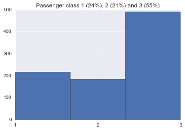

```python
#Pclass: plot:
rate1 = pclass_pc['PassengerId'].loc[1]
rate2 = pclass_pc['PassengerId'].loc[2]
rate3 = pclass_pc['PassengerId'].loc[3]
plt.title('Passenger class 1 ({:.0f}%), 2 ({:.0f}%) and 3 ({:.0f}%)'.format(rate1,rate2,rate3))
df['Pclass'].hist(bins=3);
plt.xticks([1,2,3]);
```

714 of 891 passengers have an Age data value

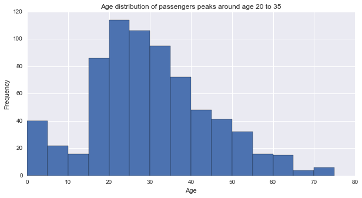

```python
bin_range = range(0,int(math.ceil(max(df['Age']))),5);
df['Age'].plot.hist(figsize=(10,5),bins=bin_range);
plt.title('Age distribution of passengers peaks around age 20 to 35');
plt.xlabel('Age');
```

All 'Sex' column values are either 'male' or 'female'.

```python
df['Sex'].describe()
```

```
count      891
unique       2
top       male
freq       577
Name: Sex, dtype: object
```

```python
sex_count = df[['PassengerId','Sex']].groupby('Sex').count()
sex_pc = sex_count *(100./len(df))
sex_pc
```

| Sex | PassengerId |
| --- | --- |
| female | 35.241302 |
| male | 64.758698 |

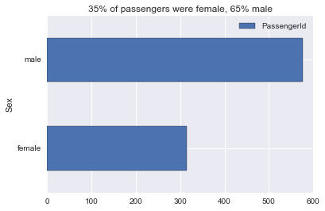

```python
sex_count.plot.barh();
plt.title('35% of passengers were female, 65% male');
```

Looks like some fares were pretty expensive.

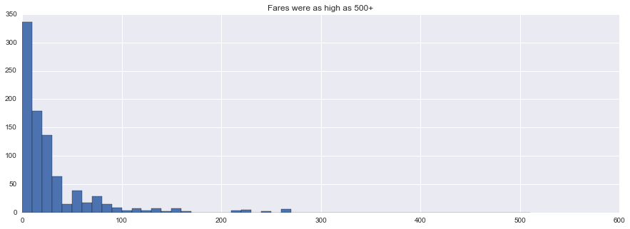

```python
bin_range = np.arange(0,max(df['Fare']),10);
df['Fare'].hist(figsize=(15,5),bins=bin_range);
plt.title('Fares were as high as 500+');
```

I don't see any data that looks like an error, so I'll work with the non-NaN data and create some categories to simplify the data into smaller groups.

## Summarize survival rates by passenger characteristics

### Females had higher survival rates than males

```python
df_by_sex = df[['Survived','Sex']].groupby('Sex').mean()
df_by_sex
```

| Sex | Survived |
| --- | --- |
| female | 0.742038 |
| male | 0.188908 |

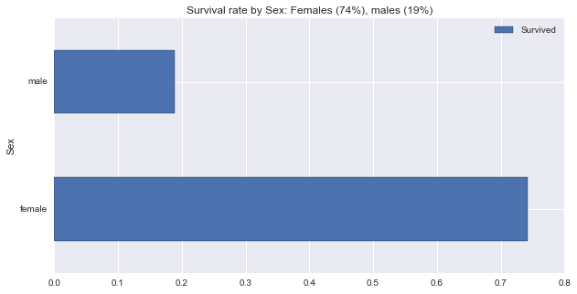

```python
df_by_sex.plot(kind='barh',figsize=(10,5));
plt.title('Survival rate by Sex: Females (74%), males (19%)');
```

### Higher class passengers had higher survival rates

```python
df_by_pclass = df[['Survived','Pclass']].groupby('Pclass').mean()
df_by_pclass
```

| Pclass | Survived |
| --- | --- |
| 1 | 0.629630 |
| 2 | 0.472826 |
| 3 | 0.242363 |

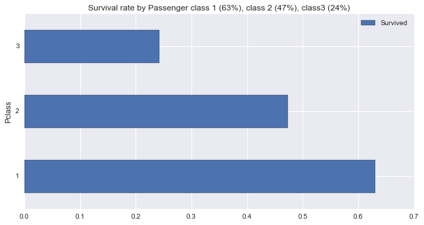

```python
df_by_pclass.plot(kind='barh',figsize=(10,5));
plt.title('Survival rate by Passenger class 1 (63%), class 2 (47%), class3 (24%)');
```

### Within each sex, higher class passengers had higher survival rates

Females survival rates were higher than males regardless of class, but within gender, higher class passengers had higher survival rates

```python
df_by_sex_pclass = df[['Survived','Sex','Pclass']].groupby(by=['Sex','Pclass']).mean()
df_by_sex_pclass
```

| Sex | Pclass | Survived |
| --- | --- | --- |
| female | 1 | 0.968085 |
|  | 2 | 0.921053 |
|  | 3 | 0.500000 |
| male | 1 | 0.368852 |
|  | 2 | 0.157407 |
|  | 3 | 0.135447 |

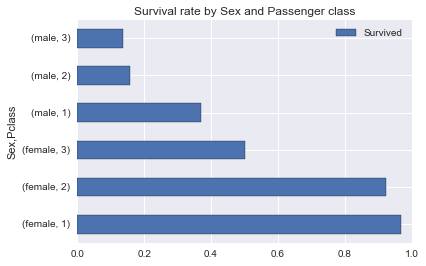

```python
df_by_sex_pclass.plot(kind='barh');
plt.title('Survival rate by Sex and Passenger class');
```

Histogram the age, but first remove rows where Age is missing

```python
df_rmna = df[df['Age'].apply(lambda x: not math.isnan(x))]
```

Bin by year, for surived and died, and for all; get the survival rate for each age range

```python
#Use pandas.cut to create a categorical data type
#the bins will include the left boundary, exclude the right boundary (set 'right' to False)
max_age = df['Age'].max()
age_bins = np.arange(0,max_age+1,1) #set the boundaries of the age bins (one year for each bin)
passenger_by_age_category = pd.cut(df_rmna['Age'],age_bins,right=False)
survived_by_age_category = pd.cut(df_rmna[df_rmna['Survived']==1]['Age'],age_bins,right=False)

#count the number of passengers and survivors for each age group
passenger_by_age_counts = passenger_by_age_category.value_counts().astype(float)
passenger_by_age_counts.sort_index(inplace=True)
survived_by_age_counts = survived_by_age_category.value_counts().astype(float)
survived_by_age_counts.sort_index(inplace=True)

#calculate the survival rate for each age group
survival_rate_by_age = survived_by_age_counts / passenger_by_age_counts

#Make the series into dataframes
df_passenger_by_age_counts = pd.DataFrame(passenger_by_age_counts)
df_survival_rate_by_age = pd.DataFrame(survival_rate_by_age)
```

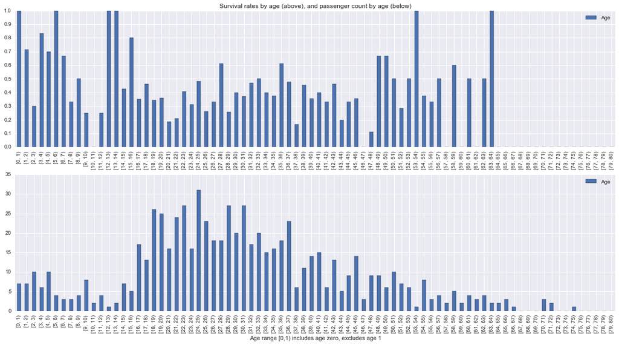

```python
#Plot survival rates as well as passenger counts
f, (axis1,axis2) = plt.subplots(2,1,figsize=(20,10))
axis1.set_title('Survival rates by age (above), and passenger count by age (below)');
df_survival_rate_by_age.plot(kind='bar',yticks=np.arange(0,1.1,0.1),ax=axis1);
df_passenger_by_age_counts.plot(kind='bar',ax=axis2);
axis2.set_xlabel('Age range [0,1) includes age zero, excludes age 1');
```

### Males with family onboard had higher survival rates than males who traveled alone

See how having a sibling or spouse, or parent or child, was related to survival rates. Perhaps having another family member made it more likely for someone to survive. For instance, if women and children were given priority on the life boats, then anyone related to a woman or child (even men) may have been given priority to board the life boats.

Most passengers traveled alone, and some traveled with one other family member, while very few traveled with more than one family member. I'll add a column 'Family', with 1 for those that had at least 1 family member, zero otherwise.

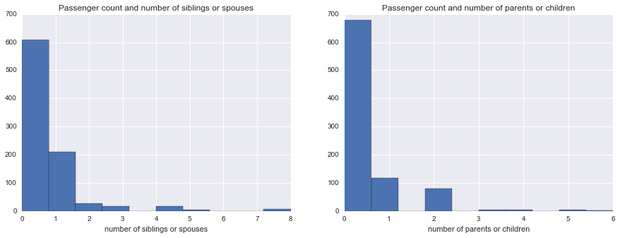

```python
fig, (axes1, axes2) = plt.subplots(1,2,figsize=(15,5))
axes1.hist(df['SibSp']);
axes1.set_title('Passenger count and number of siblings or spouses');
axes1.set_xlabel('number of siblings or spouses');
axes2.hist(df['Parch']);
axes2.set_title('Passenger count and number of parents or children');
axes2.set_xlabel('number of parents or children');
```

Create column 'Family', which has 1 if passenger had at least 1 sibling, spouse, parent or child

```python
has_sibsp = df['SibSp'] >=1
has_parch = df['Parch'] >=1
has_sibsp_parch = has_sibsp | has_parch
ser_family = pd.Series([1 if x else 0 for x in has_sibsp_parch])
df['Family'] = ser_family
```

```python
df.head()
```

|  | PassengerId | Survived | Pclass | Name | Sex | Age | SibSp | Parch | Ticket | Fare | Cabin | Embarked | Family |
| --- | --- | --- | --- | --- | --- | --- | --- | --- | --- | --- | --- | --- | --- |
| 0 | 1 | 0 | 3 | Braund, Mr. Owen Harris | male | 22.0 | 1 | 0 | A/5 21171 | 7.2500 | NaN | S | 1 |
| 1 | 2 | 1 | 1 | Cumings, Mrs. John Bradley (Florence Briggs Th... | female | 38.0 | 1 | 0 | PC 17599 | 71.2833 | C85 | C | 1 |
| 2 | 3 | 1 | 3 | Heikkinen, Miss. Laina | female | 26.0 | 0 | 0 | STON/O2. 3101282 | 7.9250 | NaN | S | 0 |
| 3 | 4 | 1 | 1 | Futrelle, Mrs. Jacques Heath (Lily May Peel) | female | 35.0 | 1 | 0 | 113803 | 53.1000 | C123 | S | 1 |
| 4 | 5 | 0 | 3 | Allen, Mr. William Henry | male | 35.0 | 0 | 0 | 373450 | 8.0500 | NaN | S | 0 |

```python
df_by_family = df[['Survived','Family']].groupby('Family').mean()
df_by_family
```

| Family | Survived |
| --- | --- |
| 0 | 0.303538 |
| 1 | 0.505650 |

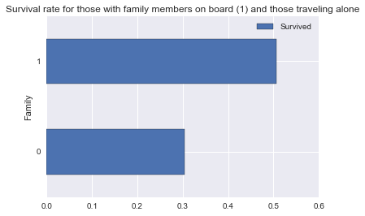

```python
df_by_family.plot.barh();
plt.title('Survival rate for those with family members on board (1) and those traveling alone');
```

```python
df_sex_family = df[['Survived','Sex','Family']].groupby(['Sex','Family']).mean()
df_sex_family
```

| Sex | Family | Survived |
| --- | --- | --- |
| female | 0 | 0.785714 |
|  | 1 | 0.712766 |
| male | 0 | 0.155718 |
|  | 1 | 0.271084 |

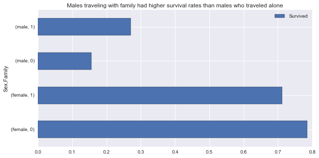

```python
df_sex_family.plot.barh(figsize=(10,5));
plt.title('Males traveling with family had higher survival rates than males who traveled alone');
```

## Summary

Although we cannot say for sure whether these traits influenced each passenger's chances of survival, we can tie in some historical information to posit an educated guess. When giving priority to board the lifeboats, women and children were supposedly given priorty, as well as upper class passengers. Those males who were traveling with another family member (perhaps a woman or a child), may have also been granted an exception to the 'women and children' rule, and could have stood a better chance of boarding a lifeboat and surviving.

# Resources

https://www.kaggle.com/c/titanic/data Description of the data.

http://pandas.pydata.org/pandas-docs/stable/generated/pandas.cut.html How to cut data into bins.

https://en.wikipedia.org/wiki/Sinking_of_the_RMS_Titanic Mentions priority given to women and children to board life boats.